# Logistic Regression

Machine Learning - Section $3.1.4$

Marc Omar Haddad

Published: 22 February, 2020

**Updated: 23 February, 2020**

**Logistic Regression** is an extension of linear regression that **ensures our estimated Conditional Probabilities are between $0$ and $1$**.

Logistic Regression requires a **logistic transformation** of our outcomes:
$$g(p)=\mathrm{log} \frac{p}{1-p}$$

Logistic transformation converts *Probabilities* to *Log Odds*. **Log Odds** tell us how much more likely an event will happen versus *not* happen. For example: If $p = 0.5$ the odds are $1:1$.

We use logistic transformation because it transforms probabilities to be symmetric around $0$.

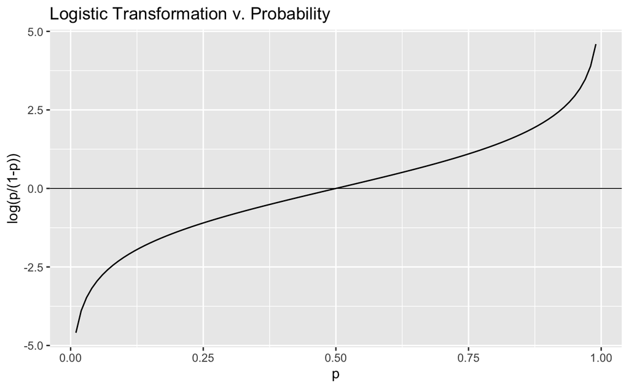

To fit this model we use the **Maximum Likelihood Estimate (MLE)**. The `R` function `glm()` (which stands for “Generalized Linear Models”) allows us to fit a logistic regression model.

```r
# The following fits a logistic regression model to our data.
glm_fit = train_set %>%
  mutate(y = as.numeric(sex == "Female")) %>%
  glm(y ~ height, data = ., family = "binomial") # Note: 'family' is required for glm().
```

Since `glm()` is more generalized than `lm()`, we are required to specify our desired model through the `family` parameter.

Similarly to our linear regression model we can obtain predictions with the `predict()` function.

```r
p_hat_logit = predict(glm_fit, newdata = test_set, type = "response")
# 'type' param must be set to 'response' if we want conditional probs.
```

We can see how well our new model `p_hat_logit` fits by plotting it against our actual Conditional Probabilities (i.e. the proportions of `female` to `male` in our data set for each rounded height).

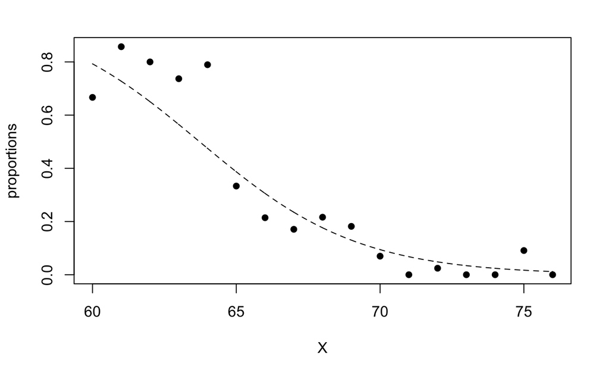

As we can clearly see, this is a much better fit than our previous linear curve (see section 3.1.3 notes).

Now let’s assess our trained algorithm by comparing the predictions to our `test_set`.

```r
confusionMatrix(y_hat_logit, test_set$sex)
```

```
Confusion Matrix and Statistics

          Reference
Prediction Female Male
    Female     31   19
    Male       87  389

               Accuracy : 0.7985
                 95% CI : (0.7616, 0.832)
    No Information Rate : 0.7757
    P-Value [Acc > NIR] : 0.1138

                  Kappa : 0.2718

 Mcnemar's Test P-Value : 7.635e-11

            Sensitivity : 0.26271
            Specificity : 0.95343
         Pos Pred Value : 0.62000
         Neg Pred Value : 0.81723
             Prevalence : 0.22433
         Detection Rate : 0.05894
   Detection Prevalence : 0.09506
      Balanced Accuracy : 0.60807

       'Positive' Class : Female
```

Though our new model accuracy ($0.7985$) is slightly higher than our previously obtained accuracy of $0.7852$, our new model does not improve much upon our previous linear model. This is due to the fact that our **Decision Rule**— predicting `female` if our estimated conditional probability is greater than $0.5$— results in similar prediction regions. This is illustrated in the graph below.

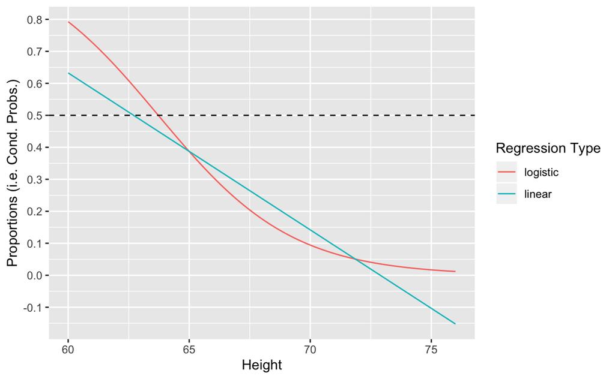

```r
height_seq2 = seq(60, 76, 0.01) # Define new height_seq w/ small intervals.

# Re-predict cond. probs. for each reg. type w/ new height_seq.
p_hat_logit2 = predict(glm_fit2, list(height = height_seq2), type = "response")
p_hat2 = predict(lm_fit, list(height = height_seq2))

df_wide = data.frame(height = height_seq2, logistic = p_hat_logit2, linear = p_hat2)

# Convert from wide-form to long-form data for ggplot.
df_long = gather(df_wide, reg_type, reg_val, logistic:linear, factor_key = TRUE)

df_long %>% ggplot(aes(height, reg_val, color = reg_type)) +
  geom_line() +
  geom_hline(yintercept = 0.5, lty = 2) +
  labs(y = "Proportions (i.e. Cond. Probs.)", x = "Height", color = "Regression Type") +
  scale_y_continuous(breaks = seq(-0.2, 0.8, 0.1))
```

Both types of regression provide an **estimate for the Conditional Expectation**; in binary data, this conditional expectation is **equivalent to Conditional Probability**.

It must be noted, however, that both logistic and linear regression are not the best approaches in more complex Machine Learning algorithms due to their rigidity. More appropriate techniques (to be learned in later sections) allow for more flexibility and are primarily **approaches to *estimating* Conditional Probabilities and/or Conditional Expectations**.